# R Guidance for PHI

## 8.4 Arranging Multiple Plots

If you need to make multiple plots it’s easier to assign the plots to objects - these are assigned in the same way as everything else using `<-`:

```r
# Assign as p1 - nothing is displayed, but object is saved in environment
# First, call ggplot() and define data and x/y variables
p1 <- ggplot(data = df, aes(x = Sepal.Length, y = Petal.Length)) +
geom_point(aes(color = Species)) + #Add a layer and change colour by Species
scale_color_brewer(palette = "Dark2") +
xlab("Sepal Length") + ylab("Petal Length") +
ggtitle(paste(Sys.Date(),"Iris Plot - Length")) #Add title
```

`p1` will appear in the global environment and can be accessed by entering it’s name into console:

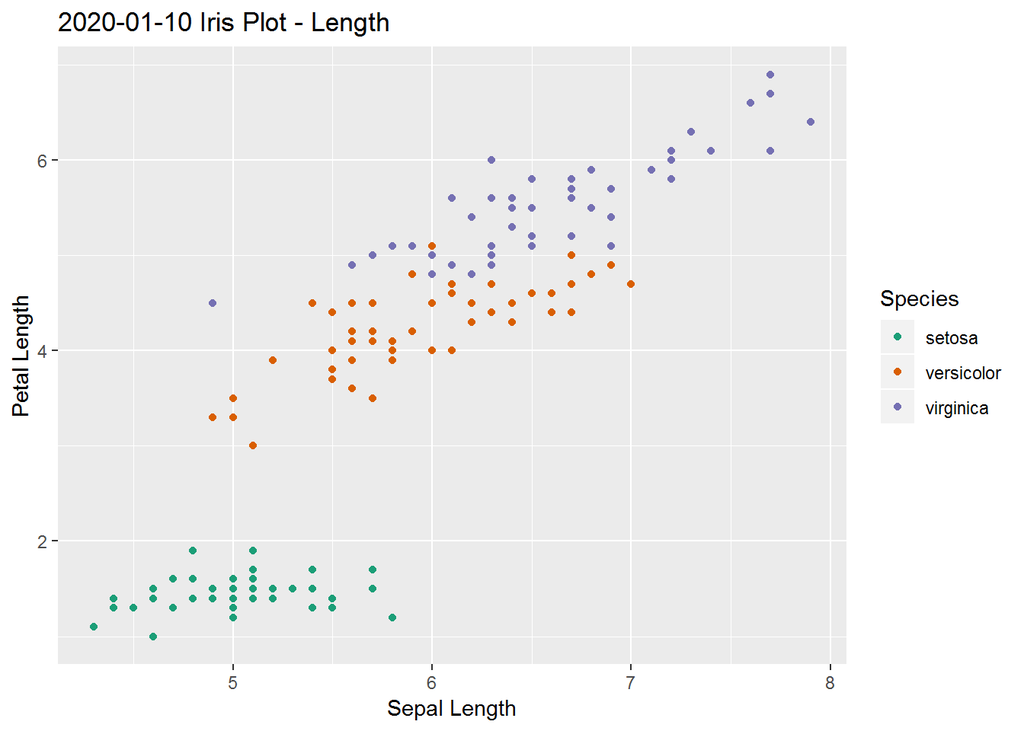

```r
#Calling p1 will display plot
p1
```

```r
# Assign as p2 - nothing is displayed, but object is saved in environment
# First, call ggplot() and define data and x/y variables
p2 <- ggplot(data = df, aes(x = Sepal.Width, y = Petal.Width)) +
geom_point(aes(color = Species)) + #Add a layer and change colour by Species
scale_color_brewer(palette = "Dark2") +
xlab("Sepal Width") + ylab("Petal Width") +
ggtitle(paste(Sys.Date(),"Iris Plot - Width")) #Add title
```

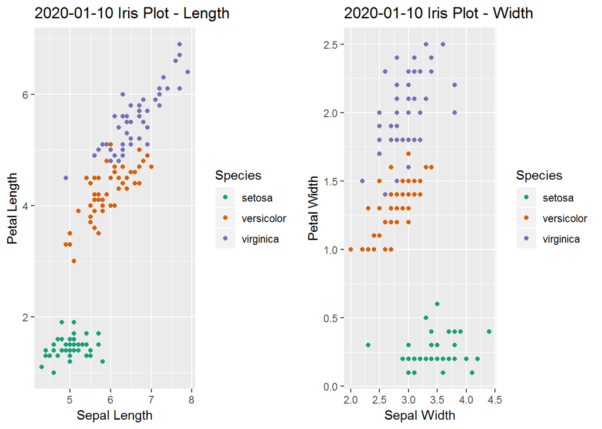

```r
# Load the package - remember to install first
library(cowplot)

# Arrange plots in grid
plot_grid(p1, p2)
```

You can state the number of rows and columns using `nrow` and `ncol`:

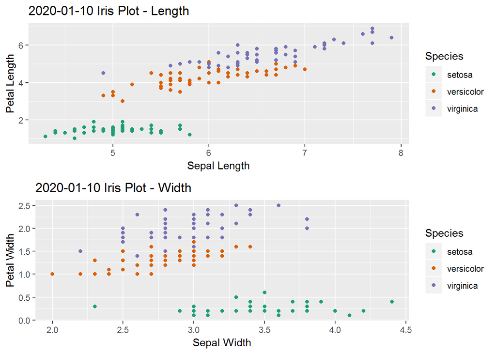

```r
# Arrange plots in one column
plot_grid(p1, p2, ncol = 1)
```

Note that here the plots are slightly misaligned - the different scales on the y axis mess this up. You can align properly - use `align()` and `axis()` to control:

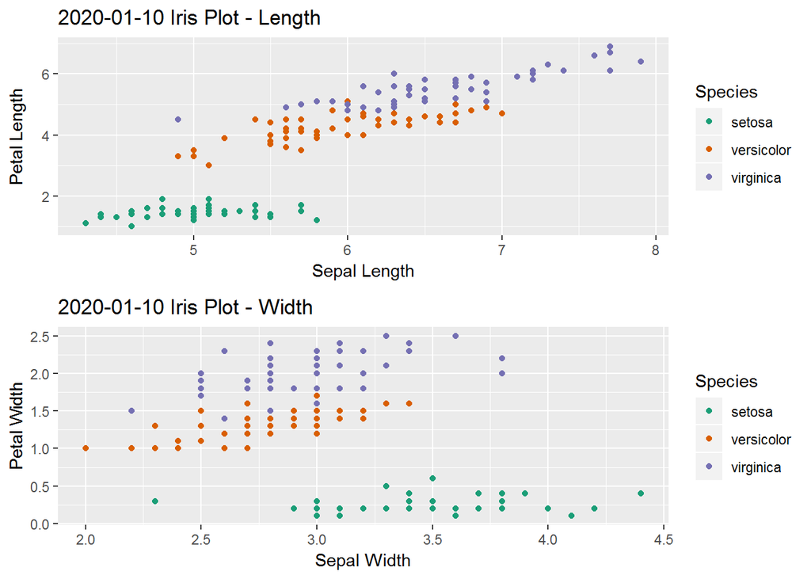

```r
# Arrange plots in one column and align both horizontally and vertically along all axis ("tblr" = top, bottom, left and right)
plot_grid(p1, p2, ncol = 1, align = "hv")
```

## 8.5 Saving Output

You can export these plots the same way as outlined in [Saving the output], but you can also do this using the function `save_plot()` from `cowplot` or `ggsave` from `ggplot`.

```r
# Arrange plots in grid and save as an object
p1_p2_grid <- plot_grid(p1, p2, ncol = 1, align = "hv")

save_plot(filename = "path/filename.pdf", #Change to where you want to save
          plot = p1_p2_grid, #Object to save
          base_height = 6, #Height in inches
          base_width = 6) #Width in inches
```

# 9 Solutions to Exercises

## 9.1 Solutions to Importing and Exporting Data

### 9.1.1 Exercise 3.1

```r
# Reading in the BORDERS (inc Age) data
Borders_age <- read_csv("H:/R Training Data/BORDERS (inc Age).csv")
```

## 9.2 Solutions to Frequencies

### 9.2.1 Exercise 4.1

```r
# Read in the Borders data
Borders <- read_csv("H:/R Training Data/Borders.csv")
```

```r
# Get the frequencies for sex
table(Borders$Sex)
```

### 9.2.2 Exercise 4.2

```r
# Calculate the mean length of stay
mean(Borders$LengthOfStay)
```

```r
# Calculate the median length of stay
median(Borders$LengthOfStay)
```

```r
# Calculate the maximum length of stay
summary(Borders$LengthOfStay)
```

## 9.3 Solutions to Crosstabs

### 9.3.1 Exercise 4.3

```r
# Create a crosstab for MOP and Specialty
addmargins(table(Borders$MOP, Borders$Specialty))
```

### 9.3.2 Exercise 4.4

```r
# Create a crosstab for MOP and Specialty
addmargins(table(Borders$Specialty, Borders$MOP))
```

## 9.4 Solutions to Data Manipulation - Using Multiple Conditions

### 9.4.1 Exercise 5.1

```r
# Calculate how many patients had a length of stay of between 2 and 6 days
# Use the filter() function on Borders for patients who had a LengthOfStay of at least 2 days and at most 6 days
Borders_6.1a <- filter(Borders, LengthOfStay >= 2 & LengthOfStay <= 6)
```

### 9.4.2 Exercise 5.2

```r
# Calculate how many men had a length of stay of over 7 days at hospital B120H or hospital S116H
# Use the filter() function on Borders for patients who had a LengthOfStay of more than 7 days and attended either hospital B120H or S116H
# The use of brackets is important here
# If brackets are not included then this will filter for patients with LengthOfStay > 7 at hospital B120H and also for all patients at hospital S116H
Borders_6.2 <- filter(Borders, LengthOfStay > 7 & (HospitalCode == "B120H" | HospitalCode == "S116H"))
```

### 9.4.3 Exercise 5.3

```r
# Calculate how many records had an admission date from 01/01/2015 up to and including 30/04/2015
# Use the filter() function on Borders for patients who were admitted on at least 20150101 and at most 20150430
Borders_6.3 <- filter(Borders, DateofAdmission >= 20150101 & DateofAdmission <= 20150430)
```

## 9.5 Solutions to Data Manipulation - `group_by()`, `summarise()` and `count()`

### 9.5.1 Exercise 5.4

```r
# Group the data by HospitalCode and Sex and calculate the counts for each combination
# Take the Borders data and use the group_by() function on HospitalCode and Sex
# Calculate the counts for each HospitalCode and Sex with the summarise() function
# Remember to ungroup the data
Borders_6.4 <- Borders %>%
  group_by(HospitalCode, Sex) %>%
  summarise(count = n()) %>%
  ungroup()
```

### 9.5.2 Exercise 5.5

```r
# Filter the dataset for patients with a LengthOfStay value of at least 4 days. Group by Specialty and calculate the mean LengthOfStay for each. Sort the data by mean LengthOfStay in descending order
# Take the Borders data and filter for patients with LengthOfStay of at least 4 days
# Use the group_by() function to group the dataset by Specialty and then calculate the mean LengthOfStay using summarise()
# Ungroup the dataset and use arrange() to order the data by mean LengthOfStay in descending order
Borders_6.5 <- Borders %>%
  filter(LengthOfStay >= 4) %>%
  group_by(Specialty) %>%
  summarise(mean_LOS = mean(LengthOfStay)) %>%
  ungroup() %>%
  arrange(desc(mean_LOS))
```

### 9.5.3 Exercise 5.6

```r
#Use count() to group Borders by HBRes and Sex and then calculate the summary counts for each grouping
Borders %>% count(HBRes, Sex)
```

```
## # A tibble: 29 x 3
##    HBRes       Sex     n
##    <chr>     <dbl> <int>
##  1 S08000015     1     6
##  2 S08000015     2     3
##  3 S08000016     1 11323
##  4 S08000016     2 12660
##  5 S08000016     3     2
##  6 S08000016    NA     9
##  7 S08000017     1    12
##  8 S08000017     2    12
##  9 S08000018     1     5
## 10 S08000018     2     4
## # ... with 19 more rows
```

## 9.6 Solutions to Formatting Data in R - Adding in Leading Zeros

### 9.6.1 Exercise 6.1

```r
# Reformat the admissiondate and dischargedate columns from the Borders (inc Age).csv file to a DD/MM/YYYY format.
# Use the mdy() function from lubridate as the dates are listed in an American format. Use mutate() to change the columns to dates.
Borders_age <- Borders_age %>%
  mutate(admissiondate = mdy(admissiondate),
         dischargedate = mdy(dischargedate))
```

### 9.6.2 Exercise 6.2

```r
# Add leading zeros to the dobdd column in the DOCTORS.csv file.
# Use the str_pad() function with width = 2, format set as integers and add a 0 to fill space
docs$dobdd <- str_pad(docs$dobdd, width = 2, pad = "0")
```

## 9.7 Solutions to Data Visualisation

### 9.7.1 Exercise 7.1

```r
# Read in Borders (inc Age) data
Borders_age <- read_csv("H:/R Training Data/BORDERS (inc Age).csv")
```

```r
# Calculate the frequencies for discharge day
counts <- table(Borders_age$dischargeday)
```

```r
# Create a barplot for discharge day and add a title and labels
barplot(counts, xlab="Discharge Day", ylab="Frequency", main="Frequency of Discharge Days")
```

### 9.7.2 Exercise 7.2

```r
# Create a histogram for length of stay and add a title and labels
hist(Borders_age$LengthOfStay, main="Histogram of Length of Stay", xlab="Length of Stay", ylab="Number of Admissions")
```

# 10 Resources

[dplyr](https://dplyr.tidyverse.org/)

[PHI Intro to R in NSS](https://github.com/Health-SocialCare-Scotland/R-Resources/blob/master/Intro%20to%20R-NSS.md)

[NSS R Resources Dashboard](https://scotland.shinyapps.io/nhs-r-resources/)

[PHI Project](https://github.com/Health-SocialCare-Scotland/phiproject)

[R for Data Science](http://r4ds.had.co.nz/)

[Rounding Methods in Different Software](https://www.isdscotland.org/About-ISD/Methodologies/_docs/Rounding-Methods-in-Different-Software_v1-0.pdf)

[SPSS Syntax to R](https://www.isdscotland.org/About-ISD/Methodologies/_docs/SPSS-syntax-to-R_v1-1.pdf)

[Using R with SMRA](http://genss.nss.scot.nhs.uk/pls/portal/docs/PAGE/GENSS_DIVISION/DIVISIONS/PHISSBU/PHIANALYSIS/PHIANMETHODOLOGIES/USING-R-WITH-SMRA-V1-1.PDF)

# 11 Help

If you have questions or need help, you can contact:

PHI R User Group Inbox: nss.Rusergroupinbox@nhs.net  
PHI R User Group Distribution List: nss.rusergp@nhs.net (you can find it by searching “rusergp” in Address Book).